# Paper: “Hyperspectral”

## General

- Using machine-learning algorithms to model defoliation of *Pinus Radiata* trees.
- keywords
  - high-dimensional data handling
  - feature selection
  - machine-learning
  - ecology
- Compare filtering methods (ensemble filter methods) across various algorithms and datasets
- Predict defoliation to all available plots (24) and the whole Basque Country (at 200 m resolution)

## Data

The data is stored at [Figshare](https://figshare.com/account/home#/projects/58613). Size is around 20 GB. Data will be downloaded into `data/` and processed when recreating the project as suggested.

**Tree data**

Four in-situ plot data from fall 2016:

- Laukiz 1
- Laukiz 2
- Luiando
- Oiartzun

**Hyperspectral data**

- Coverage: 28 plots across the Basque Country.
- Spatial Res.: 1 m
- 126 bands (bands 1-4 corrupt)

## Benchmark design

### Algorithms

- Penalized regression (LASSO, RIDGE, elastic net)
- SVM (Support Vector Machine)
- RF (Random Forest)
- XGBOOST (Extreme Gradient Boosting)

#### Datasets (3)

- Hyperspectral bands
- Normalized Ratio Indices (NRI)
- Vegetation Indices (VI)

## Hyperparameter tuning

Sequential model-based optimization (SMBO)

Initial design: 30 settings Maximum iterations: 100

## Resampling

Nested cross-validation with four folds (plot level).

## Performance measure

Root Mean Squared Error (RMSE)

## Prediction

- To remaining available plots (24) at 1 m resolution.
- To the whole Basque Country at 200 m resolution.

## Workflow

This project is setup with a [drake workflow](https://github.com/ropensci/drake), ensuring reproducibility. Intermediate targets/objects will be stored in a hidden `.drake` directory.

The R library of this project is managed by [packrat](https://rstudio.github.io/packrat/). This makes sure that the exact same package versions are used when recreating the project. When calling `packrat::restore()`, all required packages will be installed with their specific version.

Please note that this project was built with R version 3.5.2 on a Debian 9 operating system. The packrat packages from this project **are not compatible with R versions prior version 3.5.0.** For reproducibility, it is recommended to replicate the analysis using the included Dockerfile. Instructions can be found [ħere](https://github.com/pat-s/pathogen-modeling#docker). (In general, it should be possible to reproduce the analysis on any other operating system.)

To clone the project, a working installation of `git` is required. Open a terminal in the directory of your choice and execute:

```bash
git clone git@github.com:pat-s/paper_hyperspectral.git
```

Then start R in this directory and run

```r
packrat::restore()
source("code/drake.R")
make(plan, keep_going = TRUE, console_log_file = stdout())
# use more cores with make(plan, jobs = <number of cores>)
```

## Runtime

Predicted total runtime (based on all target runtimes ever built and stored in the internal `config` file)

```r
source("code/drake.R")
predict_runtime(config, from_scratch = TRUE)
```

```
## [1] "3233.5s (~53.89 minutes)"
```

Acceleration when parallelizing the `make()` call

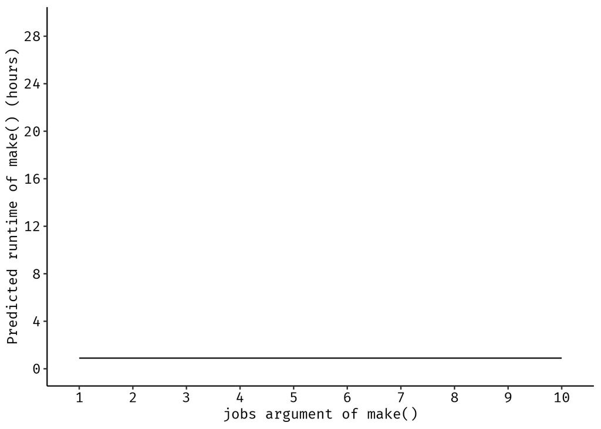

```r
time <- c()
for (jobs in 1:10){
  time[jobs] <- predict_runtime(
    config,
    jobs = jobs,
    from_scratch = TRUE,
    known_times = build_times(targets_only = TRUE)$elapsed
  )
}

library(ggplot2)
ggplot(data.frame(time = time / 3600, jobs = ordered(1:10), group = 1)) +
  geom_line(aes(x = jobs, y = time, group = group)) +
  scale_y_continuous(breaks = 0:10 * 4, limits = c(0, 29)) +
  ggpubr::theme_pubr() +
  xlab("jobs argument of make()") +
  ylab("Predicted runtime of make() (hours)")
```

## Dependency graphs

The dependency graph of this analysis can be visualized with the following code. The grouping via the `"stage"` variable is subjective.

[output not shown]

```r
vis_drake_graph(config, group = "stage", clusters = c("data", "task", "learner",
                                                      "mlr_settings",
                                                      "prediction"),
                targets_only = TRUE, show_output_files = FALSE,
                navigationButtons = FALSE
                )
```

All outdated targets:

```r
outdated(config)
```

```
##  [1] "coords"             "coords_bands"       "coords_vi_nri"
##  [4] "data_bands"         "data_bands_clean"   "data_bands_log"
##  [7] "data_ls"            "data_mod"           "data_nri"
## [10] "data_nri_log"       "data_vi"            "data_vi_log"
## [13] "data_vi_nri_clean"  "hyperspecs"         "ndvi_rasters"
## [16] "nri_indices"        "task_bands"         "task_nri"
## [19] "task_vi"            "trees_with_bands"   "trees_with_indices"
## [22] "veg_indices"        "X.multisession."
```

If all intermediate objects should be visualized (not recommended):

```r
vis_drake_graph(config) + ggpubr::theme_pubr()
```

## Literature

- What to do first (Feature selection or tuning): https://datascience.stackexchange.com/a/19778/24475
- Hastie, T., Friedman, J., & Tibshirani, R. (2001). The Elements of Statistical Learning. Springer New York. https://doi.org/10.1007/978-0-387-21606-5 (Kapitel 16)
- FSel algs overview: http://featureselection.asu.edu/algorithms.php
- De Jay, N., Papillon-Cavanagh, S., Olsen, C., El-Hachem, N., Bontempi, G., & Haibe-Kains, B. (2013). mRMRe: an R package for parallelized mRMR ensemble feature selection. Bioinformatics, 29(18), 2365–2368. https://doi.org/10/f48vxc
- Drotár, P., Gazda, J., & Smékal, Z. (2015). An experimental comparison of feature selection methods on two-class biomedical datasets. Computers in Biology and Medicine, 66, 1–10. https://doi.org/10/f72ttc
- Drotár, P., Šimoňák, S., Pietriková, E., Chovanec, M., Chovancová, E., Ádám, N., … Biňas, M. (2017). Comparison of Filter Techniques for Two-Step Feature Selection. COMPUTING AND INFORMATICS, 36(3), 597–617. https://doi.org/10/gbntp7
- Drotár, P., Gazda, M., & Gazda, J. (2017). Heterogeneous ensemble feature selection based on weighted Borda count. In 2017 9th International Conference on Information Technology and Electrical Engineering (ICITEE) (pp. 1–4). https://doi.org/10.1109/ICITEED.2017.8250495
- Nie, F., Huang, H., Cai, X., & Ding, C. H. (2010). Efficient and Robust Feature Selection via Joint 2,1-Norms Minimization. In J. D. Lafferty, C. K. I. Williams, J. Shawe-Taylor, R. S. Zemel, & A. Culotta (Eds.), Advances in Neural Information Processing Systems 23 (pp. 1813–1821). Curran Associates, Inc. Retrieved from http://papers.nips.cc/paper/3988-efficient-and-robust-feature-selection-via-joint-l21-norms-minimization.pdf